# Reproducible Research-PA1

-So we start by reading our data and remove the missing values

```r
data <- read.csv("./activity_data/activity.csv",as.is = TRUE)
acts <- data[complete.cases(data),]
```

-Now we calculate the total number of steps taken per day and make a histogram

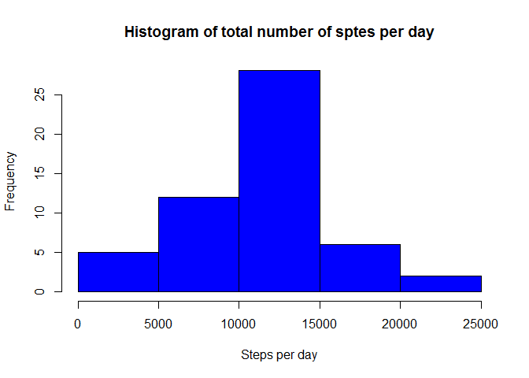

```r
day_sums <- tapply(acts$steps,acts$date,sum)

hist(day_sums,col = "blue",main = "Histogram of total number of sptes per day",xlab = "Steps per day")
```

-Then we calculate the mean and the median of the total number of steps

```r
round(mean(day_sums))
```

```
## [1] 10766
```

```r
median(day_sums)
```

```
## [1] 10765
```

Next we will calculate the average number of steps taken for every interval and make a plot of the 5-minute interval (x-axis) and the average number of steps taken, averaged across all days (y-axis).Also we will find which 5-minute interval, on average across all the days in the dataset, contains the maximum number of steps

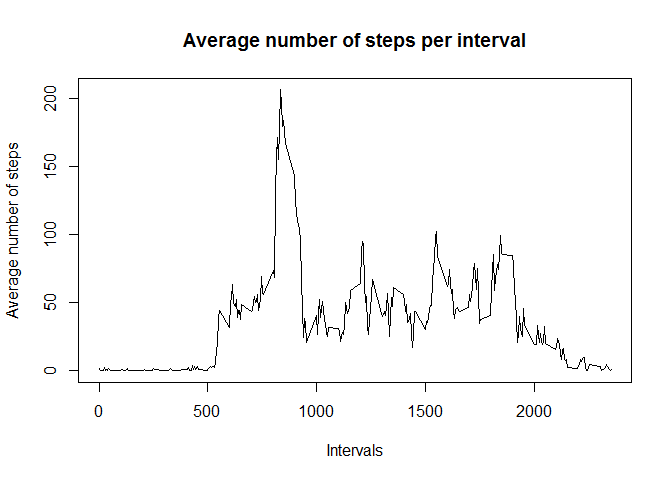

```r
int_steps <- tapply(acts$steps, acts$interval, mean)

plot(unique(acts$interval),int_steps,type = 'l',main = "Average number of steps per interval",xlab = "Intervals",ylab = "Average number of steps")
```

```r
indices <- unique(data$interval)

Max_int <- indices[which.max(int_steps)]
```

-So the interval with the max number of steps is 835

-The total number of missing values in the data set is

```r
sum(!complete.cases(data))
```

```
## [1] 2304
```

-Now we will create a new dataset that is equal to the original dataset but with the missing data filled in. We will do this by replacing the missing values with the averages of steps taken for every interval

```r
data1 <- data

for (i in 1:length(data1$steps)) {
        if(is.na(data1$steps[i])) {
                data1$steps[i] <- int_steps[which(indices == data1$interval[i])]
        }
}
```

-And next we will calculate the total number of steps per day for this dataset and make a histogram

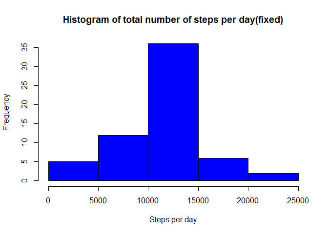

```r
day_sums1 <- tapply(data1$steps, data1$date, sum)

hist(day_sums1,col = "blue",main = "Histogram of total number of steps per day(fixed)",xlab = "Steps per day")
```

-Then we calculate the mean and the median of the total number of steps for this dataset

```r
round(mean(day_sums1))
```

```
## [1] 10766
```

```r
round(median(day_sums1))
```

```
## [1] 10766
```

-We can see that the mean and the median are not changed a lot when we fill in the missing values

-At last we will create a new factor variable in the dataset with two levels – “weekday” and “weekend” indicating whether a given date is a weekday or weekend day and then we will make a panel plot of the 5-minute interval (x-axis) and the average number of steps taken, averaged across all weekday days or weekend days (y-axis)

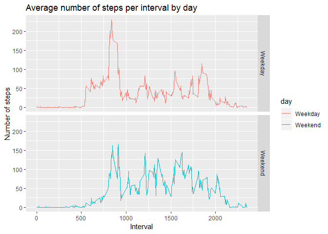

```r
dayz <- weekdays(as.Date(data1$date))
day_names <- levels(factor(dayz))
for (i in 1:length(dayz)) {
        if(dayz[i]==day_names[2] | dayz[i]==day_names[5]) {
                data1$day[i] <- "Weekend"
        } else {
                data1$day[i] <- "Weekday"
        }
}

data2 <- aggregate(steps~interval+day,data1,mean)

# now we make the plot

library(ggplot2)
myplot <- ggplot(data2,aes(interval,steps)) + geom_line(stat = "identity",aes(colour = day)) + facet_grid(day~.) + labs(x = "Interval",y = "Number of steps",title = "Average number of steps per interval by day")

print(myplot)
```